None

# Trading data task by Ehsan Ghani:

# Section 1: Campaign Scenarios.

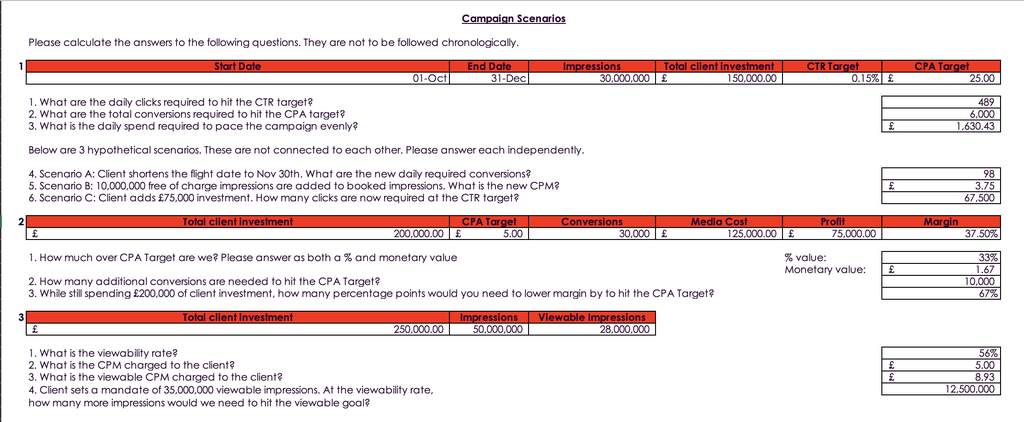

# Section 2 and 3: Display and Video data set task.

This analysis covers two distinct datasets for the Video and Display advertising campaigns. The data was imported from separate Excel files into pandas DataFrames to facilitate respective evaluations.

The decision to use Python for this task was driven by a desire to showcase and further develop my skills in data analysis and programming.

My checklist with respect to the briefs in both data sets is as follows:

1 . **Checking and cleaning the data.**

2 . **Feature Engineering with respect to the brief.**

3 . **Creating the Pivot Table for exploratory analysis.**

4 . **Summarising my findings and suggesting areas for optimisation.**

## Display data set:

### Data inspection:

Before conducting analysis, my process begins with the importation and cleansing of data. From experience, .xlsx files have typically been the most consistent of data sets, through either efficient data handling and built-in methods such as autofill. Nevertheless, this inspection will give me insight into the dataset's structure, confirm data types, and identify any potential inconsistencies or errors before analysis begins.

```
--- Data Types and Non-Null Counts ---
<class 'pandas.core.frame.DataFrame'>
RangeIndex: 223139 entries, 0 to 223138
Data columns (total 12 columns):
 #   Column                              Non-Null Count   Dtype
---  ------                              --------------   -----
 0   Site Domain                         223139 non-null  object
 1   Strategy                            223139 non-null  object
 2   Strategy Type                       223139 non-null  object
 3   Size                                223139 non-null  object
 4   Seller Name                         223139 non-null  object
 5   Impressions                         223139 non-null  int64
 6   Clicks                              223139 non-null  int64
 7   PV Conversions                      223139 non-null  int64
 8   PC Conversions                      223139 non-null  int64
 9   Media Cost                          223139 non-null  float64
 10  Total Conversions                   223139 non-null  int64
 11  Total Revenue Generated from Sales  223139 non-null  float64
dtypes: float64(2), int64(5), object(5)
memory usage: 20.4+ MB

--- Summary of Missing Values ---
Site Domain                           0
Strategy                              0
Strategy Type                         0
Size                                  0
Seller Name                           0
Impressions                           0
Clicks                                0
PV Conversions                        0
PC Conversions                        0
Media Cost                            0
Total Conversions                     0
Total Revenue Generated from Sales    0
dtype: int64
--- Head (first few rows) of data ---
```

|  | Site Domain | Strategy | Strategy Type | Size | Seller Name | Impressions | Clicks | PV Conversions | PC Conversions | Media Cost | Total Conversions | Total Revenue Generated from Sales |
| --- | --- | --- | --- | --- | --- | --- | --- | --- | --- | --- | --- | --- |
| 0 | transfermarkt.co.uk | Top Performing Domains | Prospecting | 300x250 | PubMatic | 124895 | 12 | 41 | 0 | 1815.536472 | 41 | 1398.36 |
| 1 | healthline.com | Top Performing Domains | Prospecting | 300x250 | Healthline Networks, Inc. | 49566 | 13 | 12 | 0 | 544.399897 | 12 | 352.37 |
| 2 | transfermarkt.co.uk | Top Performing Domains | Prospecting | 970x250 | PubMatic | 41784 | 17 | 14 | 0 | 568.264677 | 14 | 521.25 |
| 3 | transfermarkt.co.uk | Top Performing Domains | Prospecting | 160x600 | PubMatic | 40597 | 28 | 4 | 0 | 564.809306 | 4 | 53.41 |
| 4 | transfermarkt.co.uk | Top Performing Domains | Prospecting | 300x250 | OpenX | 30920 | 0 | 13 | 0 | 396.809928 | 13 | 860.56 |

Across the 12 features of advertisement performance the data tracks, the data is clean and complete for analysis of the campaign performance. That being said, I have noticed an increasingly large number of 0s across columns, which from past experience can affect averging and summarising key data points. I will account for this in creation of other features.

### Feature Engineering:

As requested, I have created features reflecting ROAS (return on ad spend), CPA (cost per purchase) and CPM (Cost Per Thousand/Mille).

|  | Site Domain | Strategy | Strategy Type | Size | Seller Name | Impressions | Clicks | PV Conversions | PC Conversions | Media Cost | Total Conversions | Total Revenue Generated from Sales | ROAS | CPM | CPA |
| --- | --- | --- | --- | --- | --- | --- | --- | --- | --- | --- | --- | --- | --- | --- | --- |
| 0 | transfermarkt.co.uk | Top Performing Domains | Prospecting | 300x250 | PubMatic | 124895 | 12 | 41 | 0 | 1815.536472 | 41 | 1398.36 | 0.770219 | 14.536502 | 44.281377 |
| 1 | healthline.com | Top Performing Domains | Prospecting | 300x250 | Healthline Networks, Inc. | 49566 | 13 | 12 | 0 | 544.399897 | 12 | 352.37 | 0.647263 | 10.983333 | 45.366658 |
| 2 | transfermarkt.co.uk | Top Performing Domains | Prospecting | 970x250 | PubMatic | 41784 | 17 | 14 | 0 | 568.264677 | 14 | 521.25 | 0.917266 | 13.600054 | 40.590334 |
| 3 | transfermarkt.co.uk | Top Performing Domains | Prospecting | 160x600 | PubMatic | 40597 | 28 | 4 | 0 | 564.809306 | 4 | 53.41 | 0.094563 | 13.912587 | 141.202326 |
| 4 | transfermarkt.co.uk | Top Performing Domains | Prospecting | 300x250 | OpenX | 30920 | 0 | 13 | 0 | 396.809928 | 13 | 860.56 | 2.168696 | 12.833439 | 30.523841 |

### Creating pivot tables:

The tables I have created will reflect the following points of the brief:

1 . A ROAS rank of each creative split by strategy.

2 . Ranking Strategy Types by efficiency (High ROAS & Low CPA)

I've also included a combination of ranking strategy types with Sellers to understand which seller and strategy pairings deliver the most efficient performance.

#### ROAS Rank of Creative Splits by Strategy:

This analysis identifies the top-performing ad creatives for each marketing strategy by ranking them based on their Return On Ad Spend (ROAS).

For this report, I defined the 'creative split' by the ad's Size, as different dimensions represent the primary creative variations being tested.

To achieve this, the pivot table is indexed by Size and uses Strategy as the columns. This structure effectively displays key performance indicators including Impressions, Clicks, CPA, and ROAS—for each ad size within each specific strategy. Finally, the table's output is ranked by ROAS to determine the most profitable ad sizes for each campaign.

Across all my pivot tables the aggregation logic for these metrics is split: total counts like Impressions and Clicks are calculated using sum to get a complete picture of volume. In contrast, efficiency ratios like ROAS and CPA are calculated using mean to provide a fair, normalised comparison of performance between different creative sizes and so on.

| Strategy Size | CPA Big City - Geo Targeting | CPA Health, Fitness & Nutrition Content | CPA Keywords | CPA Premium Sites | CPA Retargeting - All Pages | CPA Retargeting - Basket Page | CPA Retargeting - Product Pages | CPA Top Performing Domains | CPA All | CPM Big City - Geo Targeting | ... | ROAS All | Total Conversions Big City - Geo Targeting | Total Conversions Health, Fitness & Nutrition Content | Total Conversions Keywords | Total Conversions Premium Sites | Total Conversions Retargeting - All Pages | Total Conversions Retargeting - Basket Page | Total Conversions Retargeting - Product Pages | Total Conversions Top Performing Domains | Total Conversions All |
| --- | --- | --- | --- | --- | --- | --- | --- | --- | --- | --- | --- | --- | --- | --- | --- | --- | --- | --- | --- | --- | --- |
| 120x600 | 0.094062 | 0.214833 | 0.007192 | 0.220647 | 0.020641 | 0.004137 | 0.022675 | 0.084967 | 0.030159 | 2.349457 | ... | 38.349706 | 68 | 4 | 107 | 31 | 135 | 7 | 52 | 4 | 408 |
| 160x600 | 0.157764 | 0.150793 | 0.126741 | 4.782763 | 0.049935 | 0.004778 | 0.022454 | 3.694758 | 0.107072 | 2.920793 | ... | 43.621289 | 143 | 31 | 164 | 6 | 1221 | 26 | 526 | 22 | 2139 |
| 300x250 | 0.111111 | 1.179525 | 0.060747 | 0.860354 | 0.055472 | 0.005401 | 0.048691 | 2.184508 | 0.075606 | 2.462469 | ... | 42.236604 | 679 | 98 | 1101 | 242 | 4537 | 66 | 2091 | 106 | 8920 |
| 300x50 | 0.033056 | 0.529384 | 0.015296 | 0.110155 | 0.021158 | 0.001981 | 0.020303 | 1.059153 | 0.022759 | 2.377995 | ... | 47.658211 | 193 | 26 | 311 | 8 | 1347 | 7 | 677 | 21 | 2590 |
| 300x600 | 0.133158 | 0.462204 | 0.067229 | 0.218576 | 0.044609 | 0.001893 | 0.024789 | 1.430966 | 0.064136 | 2.544618 | ... | 34.074970 | 172 | 41 | 325 | 102 | 878 | 11 | 408 | 26 | 1963 |
| 320x50 | 0.032216 | 0.104129 | 0.005369 | 0.061768 | 0.027485 | 0.000139 | 0.034063 | 0.277270 | 0.022910 | 2.334175 | ... | 47.758123 | 166 | 15 | 408 | 30 | 2521 | 4 | 1299 | 38 | 4481 |
| 728x90 | 0.066100 | 0.418551 | 0.050208 | 0.407479 | 0.031024 | 0.002255 | 0.021550 | 0.656867 | 0.047022 | 2.523242 | ... | 44.531851 | 333 | 67 | 427 | 53 | 714 | 33 | 377 | 50 | 2054 |
| 970x250 | 0.204966 | 0.920203 | 0.032747 | 1.072658 | 0.067026 | 0.007168 | 0.021392 | 1.731598 | 0.098376 | 1.984738 | ... | 32.058197 | 70 | 38 | 98 | 16 | 208 | 7 | 76 | 26 | 539 |
| All | 0.093380 | 0.574637 | 0.040584 | 0.577950 | 0.037613 | 0.003460 | 0.031754 | 1.512044 | 0.051061 | 2.469040 | ... | 43.561015 | 1824 | 320 | 2941 | 488 | 11561 | 161 | 5506 | 293 | 23094 |

9 rows × 54 columns

```
--- Analysis by ROAS Rank ---
Most Efficient Strategy: '320x50'

Combined Rank Scores (Lower is Better):
         ROAS_Rank
Strategy
Size
320x50         1.0
300x50         2.0
728x90         3.0
160x600        4.0
300x250        5.0
120x600        6.0
300x600        7.0
970x250        8.0
```

From the analysis, the 320x50 ad size is identified as the most efficient and top-performing creative with a rank of 1.0, while the 970x250 size is the least effective. It is my recomendation that 320x50 is average size across advertisements.

#### Ranking Strategy Types by Efficiency (High ROAS & Low CPA)

This analysis ranks each strategy type (areas) on its ability to simultaneously maximize Return On Ad Spend (ROAS) and minimize Cost Per Acquisition (CPA).

Here I chose to index via strategy with strategy types (prospecting and retargeting) as columns, this layout with peformance indicators provides the most consise answer into the most efficient performers across the entire digital advertising portfolio.

Once again, splitting respective metrics by relative needs for sum (total counts) and average (rates, returns and ratios etc.).

| Strategy Type Strategy | CPA Prospecting | CPA Retargeting | CPA All | CPM Prospecting | CPM Retargeting | CPM All | Clicks Prospecting | Clicks Retargeting | Clicks All | Impressions Prospecting | Impressions Retargeting | Impressions All | ROAS Prospecting | ROAS Retargeting | ROAS All | Total Conversions Prospecting | Total Conversions Retargeting | Total Conversions All |
| --- | --- | --- | --- | --- | --- | --- | --- | --- | --- | --- | --- | --- | --- | --- | --- | --- | --- | --- |
| Big City - Geo Targeting | 0.093380 | 0.000000 | 0.093380 | 2.469040 | 0.000000 | 2.469040 | 1366 | 0 | 1366 | 5979755 | 0 | 5979755 | 12.609805 | 0.000000 | 12.609805 | 1824 | 0 | 1824 |
| Health, Fitness & Nutrition Content | 0.574637 | 0.000000 | 0.574637 | 15.276788 | 0.000000 | 15.276788 | 45 | 0 | 45 | 136192 | 0 | 136192 | 1.388794 | 0.000000 | 1.388794 | 320 | 0 | 320 |
| Keywords | 0.040584 | 0.000000 | 0.040584 | 8.917661 | 0.000000 | 8.917661 | 568 | 0 | 568 | 1837403 | 0 | 1837403 | 67.379938 | 0.000000 | 67.379938 | 2941 | 0 | 2941 |
| Premium Sites | 0.577950 | 0.000000 | 0.577950 | 6.810366 | 0.000000 | 6.810366 | 172 | 0 | 172 | 925620 | 0 | 925620 | 0.983828 | 0.000000 | 0.983828 | 488 | 0 | 488 |
| Retargeting - All Pages | 0.000000 | 0.037613 | 0.037613 | 0.000000 | 7.492108 | 7.492108 | 0 | 1171 | 1171 | 0 | 2531066 | 2531066 | 0.000000 | 44.123401 | 44.123401 | 0 | 11561 | 11561 |
| Retargeting - Basket Page | 0.000000 | 0.003460 | 0.003460 | 0.000000 | 3.457486 | 3.457486 | 0 | 48 | 48 | 0 | 39287 | 39287 | 0.000000 | 0.370226 | 0.370226 | 0 | 161 | 161 |
| Retargeting - Product Pages | 0.000000 | 0.031754 | 0.031754 | 0.000000 | 10.410328 | 10.410328 | 0 | 478 | 478 | 0 | 993892 | 993892 | 0.000000 | 27.074123 | 27.074123 | 0 | 5506 | 5506 |
| Top Performing Domains | 1.512044 | 0.000000 | 1.512044 | 11.829179 | 0.000000 | 11.829179 | 144 | 0 | 144 | 469875 | 0 | 469875 | 1.767018 | 0.000000 | 1.767018 | 293 | 0 | 293 |
| All | 0.077586 | 0.034001 | 0.051061 | 8.006341 | 8.656388 | 8.401941 | 2295 | 1697 | 3992 | 9348845 | 3564245 | 12913090 | 56.418694 | 35.291049 | 43.561015 | 5866 | 17228 | 23094 |

```
--- Analysis by Average Rank ---
Most Efficient Strategy: 'Keywords'

Combined Rank Scores (Lower is Better):
                                    ROAS_Rank CPA_Rank Average_Rank
Strategy Type
Strategy
Keywords                                  1.0      4.0          2.5
Retargeting - All Pages                   2.0      3.0          2.5
Retargeting - Product Pages               3.0      2.0          2.5
Big City - Geo Targeting                  4.0      5.0          4.5
Retargeting - Basket Page                 8.0      1.0          4.5
Health, Fitness & Nutrition Content       6.0      6.0          6.0
Top Performing Domains                    5.0      8.0          6.5
Premium Sites                             7.0      7.0          7.0
```

#### Key findings:

The updated rankings suggest that the 'Keywords','Retargeting - All Pages' and 'Retargeting - Product Pages' strategies are the most efficient overall, tying for the average rank of 2.5. The top performances are driven by a varying advantages between ROAS and CPA rankings.

This highlights a key trade-off in performance. For instance, the 'Retargeting - Basket Page' strategy achieved the best possible CPA Rank (1.0), but its extremely poor ROAS Rank (8.0) resulted in a less competitive average rank of 4.5.

From this, I can add that a balanced approach is the most effective path to overall efficiency. While specialization in one area (like the low CPA of 'Retargeting - Basket Page') is effective, the top strategies like 'Keywords' and 'Retargeting - All Pages' perform well because they achieve a strong balance between generating a high return (ROAS) and maintaining a reasonable acquisition cost (CPA).

### Visualisation with further findings:

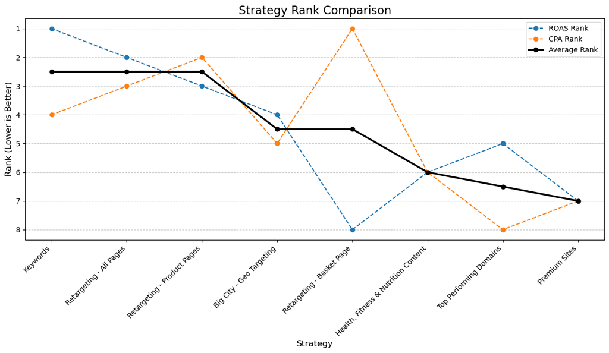

I would encourage the reader to interpret this vertically rather than horizontally. My reasoning for this stems from understanding the variability and trade-offs inherent in each strategy. While some strategies excel in one metric, they often falter in another, and a vertical interpretation is the only way to see this complete performance picture.

For instance, 'Keywords' achieves the best possible ROAS rank, but this comes at the cost of a mediocre CPA rank. Conversely, 'Retargeting - Basket Page' is the most cost-effective strategy with the best CPA rank, but it has the worst ROAS rank of all the options. This shows a clear trade-off between maximizing return and minimizing cost. The Average Rank line smooths out this variability, revealing that the most balanced and efficient strategies are those that perform consistently well across both metrics, rather than excelling at one extreme.

One could argue that the minimal betweenness of that of 'Retargeting - All Pages' and 'Retargeting - Product Pages' suggests that they are the optimal strategy, as the trade-off is minimal and the average ranks tie for highest. It is my recommendation that either should be considered as optimal, depending on whether the primary goal of chosen convenience is maximising return or minimising cost.

This graph is also the optimal example for displaying my ranking system. The strategy set is large enough for a clear interpretation that shows not only the final average rank, but also the underlying performance trade-offs. It visually demonstrates how some strategies excel at maximizing return (a low ROAS Rank) while others are better at minimizing cost (a low CPA Rank), and how the 'Average Rank' identifies the most balanced performer overall. Other Ranking systems in this assignement are just as efficient, but do not offer an as clear visual interpretation. Hence my decision to include the graph here, but not anywhere else.

#### Ranking Strategy Types with Sellers by efficiency (High ROAS & Low CPA) :

This analysis will help identify optimal partnerships, showing which sellers are best suited for specific strategic goals like prospecting or retargeting.

| Strategy | Strategy Type Seller Name | CPA Prospecting | CPA Retargeting | CPA All | CPM Prospecting | CPM Retargeting | CPM All | Clicks Prospecting | Clicks Retargeting | Clicks All | Impressions Prospecting | Impressions Retargeting | Impressions All | ROAS Prospecting | ROAS Retargeting | ROAS All | Total Conversions Prospecting | Total Conversions Retargeting | Total Conversions All |
| --- | --- | --- | --- | --- | --- | --- | --- | --- | --- | --- | --- | --- | --- | --- | --- | --- | --- | --- | --- |
| Big City - Geo Targeting | 33Across Real Impact | 0.000000 | 0.000000 | 0.000000 | 1.585768 | 0.000000 | 1.585768 | 0 | 0 | 0 | 3 | 0 | 3 | 0.000000 | 0.000000 | 0.000000 | 0 | 0 | 0 |
|  | Bauer Media UK | 0.000000 | 0.000000 | 0.000000 | 2.697101 | 0.000000 | 2.697101 | 0 | 0 | 0 | 38 | 0 | 38 | 0.000000 | 0.000000 | 0.000000 | 0 | 0 | 0 |
|  | Business Insider Inc. | 0.067900 | 0.000000 | 0.067900 | 2.233905 | 0.000000 | 2.233905 | 0 | 0 | 0 | 626 | 0 | 626 | 0.000000 | 0.000000 | 0.000000 | 3 | 0 | 3 |
|  | BuzzFeed Media Enterprises, Inc. | 0.009639 | 0.000000 | 0.009639 | 2.075601 | 0.000000 | 2.075601 | 1 | 0 | 1 | 3454 | 0 | 3454 | 0.000000 | 0.000000 | 0.000000 | 3 | 0 | 3 |
|  | Conde Nast | 0.066874 | 0.000000 | 0.066874 | 2.052162 | 0.000000 | 2.052162 | 0 | 0 | 0 | 1146 | 0 | 1146 | 4.739647 | 0.000000 | 4.739647 | 5 | 0 | 5 |
| ... | ... | ... | ... | ... | ... | ... | ... | ... | ... | ... | ... | ... | ... | ... | ... | ... | ... | ... | ... |
| Top Performing Domains | Microsoft Advertising Exchange | 0.110548 | 0.000000 | 0.110548 | 15.792635 | 0.000000 | 15.792635 | 0 | 0 | 0 | 7 | 0 | 7 | 0.000000 | 0.000000 | 0.000000 | 1 | 0 | 1 |
|  | OpenX | 0.647142 | 0.000000 | 0.647142 | 11.582583 | 0.000000 | 11.582583 | 7 | 0 | 7 | 56923 | 0 | 56923 | 0.132578 | 0.000000 | 0.132578 | 55 | 0 | 55 |
|  | PubMatic | 4.682597 | 0.000000 | 4.682597 | 12.336142 | 0.000000 | 12.336142 | 82 | 0 | 82 | 278121 | 0 | 278121 | 0.302711 | 0.000000 | 0.302711 | 98 | 0 | 98 |
|  | Trusted Media Brands Inc | 0.000000 | 0.000000 | 0.000000 | 10.004387 | 0.000000 | 10.004387 | 0 | 0 | 0 | 20 | 0 | 20 | 0.000000 | 0.000000 | 0.000000 | 0 | 0 | 0 |
| All |  | 0.077586 | 0.034001 | 0.051061 | 8.006341 | 8.656388 | 8.401941 | 2295 | 1697 | 3992 | 9348845 | 3564245 | 12913090 | 56.418694 | 35.291049 | 43.561015 | 5866 | 17228 | 23094 |

495 rows × 18 columns

```
--- Analysis by Combined Rank ---
Most Efficient Strategy: '('Retargeting - All Pages', 'Warner Media LLC')'

Combined Rank Scores (Lower is Better):
```

| Strategy | Strategy Type Seller Name | ROAS_Rank | CPA_Rank | Average_Rank |
| --- | --- | --- | --- | --- |
| Retargeting - All Pages | Warner Media LLC | 1.0 | 128.5 | 64.75 |
| Keywords | theGuardian.com | 2.0 | 128.5 | 65.25 |
|  | Gumtree.com Ltd | 3.0 | 128.5 | 65.75 |
| Retargeting - Product Pages | Internet Brands Inc. | 4.0 | 128.5 | 66.25 |
| Retargeting - All Pages | Figaromedias | 6.0 | 128.5 | 67.25 |

Here it is shown that combination of the 'Retargeting - All Pages' strategy run with the seller 'Warner Media LLC' is the most efficient pairing, achieving the lowest Average Rank of 64.75. Interestingly, all of the top five partnerships share the exact same CPA Rank (128.5). This indicates that ROAS was the sole deciding factor in this particular ranking, making the 'Warner Media LLC' partnership the most efficient sell-side partner. My suggestion is to prioritize and allocate more budget to the 'Warner Media LLC' and 'Retargeting - All Pages' combination, as it is proven to be the most profitable pairing.

## Summary of Display data set task:

. **Top Creative split:** The 320x50 ad size is the most effective creative split, outperforming all other dimensions.

. **Top Combination of strategy and sell-side partner:** The most profitable specific combination is the 'Retargeting - All Pages' strategy when run with the seller 'Warner Media LLC', as this pairing generates the highest ROAS among top-performing partners.

I will now continue with the video data set in a similar manner.

## Video data set task:

As the brief states, the goal of this campaign in three-fold:

. Maximise viewability

. Maximise video completion rate

. Minimise the cost of running the campaign.

```
--- Data Types and Non-Null Counts ---
<class 'pandas.core.frame.DataFrame'>
RangeIndex: 61387 entries, 0 to 61386
Data columns (total 12 columns):
 #   Column                               Non-Null Count  Dtype
---  ------                               --------------  -----
 0   Strategy                             61387 non-null  object
 1   App/URL                              61387 non-null  object
 2   Environment                          61387 non-null  object
 3   Inventory Source                     61387 non-null  object
 4   Browser                              61387 non-null  object
 5   Impressions                          61387 non-null  int64
 6   Clicks                               61387 non-null  int64
 7   Media Cost                           61387 non-null  float64
 8   Completions (Video)                  61387 non-null  int64
 9   Active View: Viewable Impressions    61387 non-null  int64
 10  Active View: Measurable Impressions  61387 non-null  int64
 11  Starts (Video)                       61387 non-null  int64
dtypes: float64(1), int64(6), object(5)
memory usage: 5.6+ MB

--- Summary of Missing Values ---
Strategy                               0
App/URL                                0
Environment                            0
Inventory Source                       0
Browser                                0
Impressions                            0
Clicks                                 0
Media Cost                             0
Completions (Video)                    0
Active View: Viewable Impressions      0
Active View: Measurable Impressions    0
Starts (Video)                         0
dtype: int64
--- Head (first few rows) of data ---
```

|  | Strategy | App/URL | Environment | Inventory Source | Browser | Impressions | Clicks | Media Cost | Completions (Video) | Active View: Viewable Impressions | Active View: Measurable Impressions | Starts (Video) |
| --- | --- | --- | --- | --- | --- | --- | --- | --- | --- | --- | --- | --- |
| 0 | Category | akhbarona.com | Video Desktop In-Read | DoubleClick Ad Exchange Unclassified Inventory... | Firefox | 2 | 0 | 0.016173 | 1 | 2 | 2 | 2 |
| 1 | Category | al.com | Video Desktop In-Read | DoubleClick Ad Exchange Unclassified Inventory... | Other | 5 | 0 | 0.086283 | 2 | 4 | 5 | 5 |
| 2 | Category | al.com | Video Desktop In-Read | DoubleClick Ad Exchange Unclassified Inventory... | Safari 11 | 1 | 0 | 0.017256 | 0 | 0 | 1 | 1 |
| 3 | Category | albawaba.com | Video Desktop In-Read | FreeWheel SSP Unclassified Inventory Source | Chrome | 7 | 0 | 0.041046 | 4 | 6 | 7 | 7 |
| 4 | Category | alcula.com | Video Desktop In-Read | DoubleClick Ad Exchange Unclassified Inventory... | Chrome | 19 | 0 | 0.336444 | 8 | 16 | 18 | 17 |

### Data Inspection:

As expected, the behaviour of the DataFrame is the same, efficient data handling across the board.

### Feature engineering with respect to Video data set:

Following the data inspection, this section focuses on feature engineering with respect to specific key performance indicators required by the brief. New columns such as Viewability, Video Completion Rate, CPM, CPCV, and CTR are calculated from the base metrics.

|  | Strategy | App/URL | Environment | Inventory Source | Browser | Impressions | Clicks | Media Cost | Completions (Video) | Active View: Viewable Impressions | Active View: Measurable Impressions | Starts (Video) | Viewability | Video Completion Rate | CPM | CPCV | CTR |
| --- | --- | --- | --- | --- | --- | --- | --- | --- | --- | --- | --- | --- | --- | --- | --- | --- | --- |
| 0 | Category | akhbarona.com | Video Desktop In-Read | DoubleClick Ad Exchange Unclassified Inventory... | Firefox | 2 | 0 | 0.016173 | 1 | 2 | 2 | 2 | 1.000000 | 0.500000 | 8.086500 | 0.016173 | 0.0 |
| 1 | Category | al.com | Video Desktop In-Read | DoubleClick Ad Exchange Unclassified Inventory... | Other | 5 | 0 | 0.086283 | 2 | 4 | 5 | 5 | 0.800000 | 0.400000 | 17.256600 | 0.043141 | 0.0 |
| 2 | Category | al.com | Video Desktop In-Read | DoubleClick Ad Exchange Unclassified Inventory... | Safari 11 | 1 | 0 | 0.017256 | 0 | 0 | 1 | 1 | 0.000000 | 0.000000 | 17.256000 | 0.000000 | 0.0 |
| 3 | Category | albawaba.com | Video Desktop In-Read | FreeWheel SSP Unclassified Inventory Source | Chrome | 7 | 0 | 0.041046 | 4 | 6 | 7 | 7 | 0.857143 | 0.571429 | 5.863714 | 0.010261 | 0.0 |
| 4 | Category | alcula.com | Video Desktop In-Read | DoubleClick Ad Exchange Unclassified Inventory... | Chrome | 19 | 0 | 0.336444 | 8 | 16 | 18 | 17 | 0.888889 | 0.470588 | 17.707579 | 0.042055 | 0.0 |

### Pivot tables of Video data set:

Here, I will provide two different pivot tables with respect to the brief:

. The first table reflecting rankings for strategy based on video completion rate and viewability

. The second table reflecting which areas of Browser and Environment maximimise video completion rate and viewability, but minimimise cost related attributes like CPM, CPCV.

#### Table reflecting rankings for strategy based on video completion rate and viewability:

In the construction of this table, I had to adjust the aggregation logic to reflect the performance metrics of the Video data set, which meant including viewability, video completion rate, CPCV and CTR as metrics to be averaged due to their categorisation as rates, ratios and returns. Also in configuration I had to remove App/URL from columns, with the vast set of URLs the computation was too much to summarise even categorically, so rather than include a potential computational error I decided to remove it entirely, however the table does include 'Environment', 'Browser', 'Inventory Source' as columns to reflect a macro view of the micro aspect of URLs.

| Environment Browser Inventory Source Strategy | CPCV Desktop Web Game (Video RTB) Chrome DoubleClick Ad Exchange Unclassified Inventory Source | CPCV Desktop Web Game (Video RTB) Firefox DoubleClick Ad Exchange Unclassified Inventory Source | CPCV Desktop Web Game (Video RTB) Internet Explorer 10 DoubleClick Ad Exchange Unclassified Inventory Source | CPCV Desktop Web Game (Video RTB) Internet Explorer 11 DoubleClick Ad Exchange Unclassified Inventory Source | CPCV Desktop Web Game (Video RTB) Microsoft Edge DoubleClick Ad Exchange Unclassified Inventory Source | CPCV Desktop Web Game (Video RTB) Other DoubleClick Ad Exchange Unclassified Inventory Source | CPCV Desktop Web Game (Video RTB) Safari 10 DoubleClick Ad Exchange Unclassified Inventory Source | CPCV Desktop Web Game (Video RTB) Safari 11 DoubleClick Ad Exchange Unclassified Inventory Source | CPCV Desktop Web Game (Video RTB) Safari 12 DoubleClick Ad Exchange Unclassified Inventory Source | CPCV Desktop Web Game (Video RTB) Safari 6 DoubleClick Ad Exchange Unclassified Inventory Source | ... | Viewability Video Desktop In-Read Safari 9 OpenX Unclassified Inventory Source | Viewability Video Desktop In-Read Safari 9 TeadsTv Unclassified Inventory Source | Viewability Video Desktop In-Read Safari 9 Telaria Unclassified Inventory Source | Viewability Video Desktop In-Read Safari 9 TripleLift | Viewability Video Mobile App Interstitial (Video RTB) Android Webkit DoubleClick Ad Exchange Unclassified Inventory Source | Viewability Video Mobile App Interstitial (Video RTB) Chrome DoubleClick Ad Exchange Unclassified Inventory Source | Viewability Video Mobile App Interstitial (Video RTB) Chrome Improve Digital Unclassified Inventory Source | Viewability Video Mobile App Interstitial (Video RTB) Safari DoubleClick Ad Exchange Unclassified Inventory Source | Viewability Video Mobile App Interstitial (Video RTB) Safari Improve Digital Unclassified Inventory Source | Viewability All |
| --- | --- | --- | --- | --- | --- | --- | --- | --- | --- | --- | --- | --- | --- | --- | --- | --- | --- | --- | --- | --- | --- |
| Behavioural | 0.029485 | 0.032288 | 0.033374 | 0.034677 | 0.030079 | 0.033204 | 0.038356 | 0.048920 | 0.020784 | 0.008719 | ... | 0 | 0.000000 | 0 | 0.000000 | 0.800000 | 0.832851 | 0.276423 | 0.862887 | 0.000000 | 0.758944 |
| Category | 0.032786 | 0.033458 | 0.028939 | 0.033251 | 0.033269 | 0.031410 | 0.031054 | 0.095827 | 0.016502 | 0.023161 | ... | 0 | 0.500000 | 1 | 0.500000 | 0.000000 | 0.782407 | 0.200000 | 0.785714 | 0.000000 | 0.726292 |
| Keyword | 0.000000 | 0.000000 | 0.000000 | 0.000000 | 0.000000 | 0.000000 | 0.000000 | 0.000000 | 0.000000 | 0.000000 | ... | 0 | 0.000000 | 0 | 0.000000 | 0.000000 | 1.000000 | 0.000000 | 1.000000 | 0.000000 | 0.744025 |
| Prospecting | 0.043014 | 0.039234 | 0.082674 | 0.031915 | 0.034565 | 0.050106 | 0.021547 | 0.061815 | 0.072326 | 0.000000 | ... | 0 | 0.642857 | 1 | 0.428571 | 0.500000 | 0.856447 | 0.552500 | 0.849800 | 0.615537 | 0.759286 |
| All | 0.033535 | 0.034275 | 0.035402 | 0.033425 | 0.032333 | 0.032534 | 0.031484 | 0.075018 | 0.023655 | 0.018347 | ... | 0 | 0.611111 | 1 | 0.464286 | 0.714286 | 0.842062 | 0.527365 | 0.855120 | 0.615537 | 0.750495 |

5 rows × 3598 columns

```
--- Analysis by Combined Rank ---
Most Efficient Strategy: 'Prospecting'

Combined Rank Scores (Lower is Better):
                 Viewability_Rank VCR_Rank Average_Rank
Environment
Browser
Inventory Source
Strategy
Prospecting                   1.0      1.0          1.0
Behavioural                   2.0      2.0          2.0
Category                      4.0      3.0          3.5
Keyword                       3.0      4.0          3.5
```

**Key findings:**

#### Ranking strategy with respect to additional cost factors:

In construction of this table I thought it would be best include functions of media cost, such as CPM (Cost Per Mille) and CPCV (Cost Per Completed View). This provides a more holistic view of performance, allowing for an efficiency analysis that balances engagement metrics like viewability with their associated costs.

| Browser | Strategy Inventory Source Environment | CPCV Behavioural AO - High AVOC - £12 | CPCV Behavioural AO - High Viewability 70% - £5 | CPCV Behavioural AO - O&O News and Entertainment Medium - Large Player - £12 | CPCV Behavioural AO - UK VOD - Teads - Male - £19 | CPCV Behavioural Adform Unclassified Inventory Source | CPCV Behavioural Adman | CPCV Behavioural AppNexus Unclassified Inventory Source | CPCV Behavioural Beachfront | CPCV Behavioural COL093946:DBM_Carat_Amnet_Canada_MIQ_Mattel_Q4_11.07.18-12.31.18 | CPCV Behavioural Curiosity | ... | Viewability Prospecting Sovrn Unclassified Inventory Source | Viewability Prospecting SpotX AUNZ High Viewability | Viewability Prospecting SpotX Unclassified Inventory Source | Viewability Prospecting TeadsTv Unclassified Inventory Source | Viewability Prospecting Telaria Unclassified Inventory Source | Viewability Prospecting TripleLift | Viewability Prospecting UnrulyX | Viewability Prospecting Video Intelligence | Viewability Prospecting YouTube Videos | Viewability All |
| --- | --- | --- | --- | --- | --- | --- | --- | --- | --- | --- | --- | --- | --- | --- | --- | --- | --- | --- | --- | --- | --- | --- |
| Android Webkit | Desktop Web Video (Video RTB) | 0.000000 | 0.000000 | 0.00000 | 0.000000 | 0.000000 | 0.000000 | 0.000000 | 0.000000 | 0.000000 | 0 | ... | 0.000000 | 0 | 0.000000 | 0.000000 | 0.000000 | 0.000000 | 0.000000 | 0 | 0.000000 | 0.000000 |
|  | Mobile Web | 0.000000 | 0.000000 | 0.00000 | 0.000000 | 0.000000 | 0.000000 | 0.000000 | 0.000000 | 0.000000 | 0 | ... | 0.000000 | 0 | 0.000000 | 0.000000 | 0.000000 | 0.000000 | 0.000000 | 0 | 0.000000 | 1.000000 |
|  | Video Mobile App Interstitial (Video RTB) | 0.000000 | 0.000000 | 0.00000 | 0.000000 | 0.000000 | 0.000000 | 0.000000 | 0.000000 | 0.000000 | 0 | ... | 0.000000 | 0 | 0.000000 | 0.000000 | 0.000000 | 0.000000 | 0.000000 | 0 | 0.000000 | 0.714286 |
| Chrome | Desktop Web Game (Video RTB) | 0.000000 | 0.000000 | 0.00000 | 0.000000 | 0.000000 | 0.000000 | 0.000000 | 0.000000 | 0.000000 | 0 | ... | 0.000000 | 0 | 0.000000 | 0.000000 | 0.000000 | 0.000000 | 0.000000 | 0 | 0.000000 | 0.940930 |
|  | Desktop Web Video (Video RTB) | 0.022205 | 0.019659 | 0.00000 | 0.000000 | 0.012228 | 0.018118 | 0.012926 | 0.010749 | 0.000000 | 0 | ... | 0.751742 | 1 | 0.669990 | 0.000000 | 0.784955 | 0.000000 | 0.785714 | 0 | 0.000000 | 0.745666 |
| ... | ... | ... | ... | ... | ... | ... | ... | ... | ... | ... | ... | ... | ... | ... | ... | ... | ... | ... | ... | ... | ... | ... |
| Safari 8 | Video Desktop In-Read | 0.000000 | 0.000000 | 0.00000 | 0.000000 | 0.000000 | 0.000000 | 0.000000 | 0.000000 | 0.000000 | 0 | ... | 0.000000 | 0 | 0.000000 | 1.000000 | 0.000000 | 0.000000 | 0.000000 | 0 | 0.000000 | 0.630814 |
| Safari 9 | Desktop Web Game (Video RTB) | 0.000000 | 0.000000 | 0.00000 | 0.000000 | 0.000000 | 0.000000 | 0.000000 | 0.000000 | 0.000000 | 0 | ... | 0.000000 | 0 | 0.000000 | 0.000000 | 0.000000 | 0.000000 | 0.000000 | 0 | 0.000000 | 0.905318 |
|  | Desktop Web Video (Video RTB) | 0.000000 | 0.000000 | 0.00000 | 0.000000 | 0.000000 | 0.000000 | 0.000000 | 0.000000 | 0.000000 | 0 | ... | 0.000000 | 0 | 0.500000 | 0.000000 | 1.000000 | 0.000000 | 0.000000 | 0 | 0.000000 | 0.805249 |
|  | Video Desktop In-Read | 0.000000 | 0.000000 | 0.00000 | 0.000000 | 0.000000 | 0.000000 | 0.000000 | 0.000000 | 0.000000 | 0 | ... | 0.000000 | 0 | 0.000000 | 0.642857 | 1.000000 | 0.428571 | 0.000000 | 0 | 0.000000 | 0.750118 |
| All |  | 0.022205 | 0.024616 | 0.00793 | 0.072603 | 0.012584 | 0.014829 | 0.019832 | 0.012888 | 0.055126 | 0 | ... | 0.703885 | 1 | 0.695377 | 0.778125 | 0.768453 | 0.669731 | 0.892857 | 1 | 0.961398 | 0.750495 |

63 rows × 1092 columns

```
--- Analysis by Combined Rank ---
Most Efficient Strategy: '('Microsoft Edge', 'Mobile Web')'

Combined Rank Scores (Lower is Better):
```

| Browser | Strategy Inventory Source Environment | Viewability_Rank | VCR_Rank | CPCV_Rank | CPM_Rank | Average_Rank |
| --- | --- | --- | --- | --- | --- | --- |
| Microsoft Edge | Mobile Web | 3.5 | 1.5 | 12.0 | 2.0 | 4.750 |
| Internet Explorer 9 | Desktop Web Video (Video RTB) | 34.0 | 10.0 | 9.0 | 1.0 | 13.500 |
| Safari 9 | Video Desktop In-Read | 33.0 | 30.0 | 18.0 | 11.0 | 23.000 |
| Microsoft Edge | Video Desktop In-Feed | 3.5 | 60.0 | 3.0 | 26.0 | 23.125 |
| Safari 10 | Video Desktop In-Read | 32.0 | 26.0 | 20.0 | 15.0 | 23.250 |
| ... | ... | ... | ... | ... | ... | ... |
| Other | Mobile Web | 26.0 | 38.0 | 61.0 | 54.0 | 44.750 |
| Safari 7 | Desktop Web Game (Video RTB) | 53.0 | 56.0 | 28.0 | 52.0 | 47.250 |
| Safari 12 | Desktop Web Game (Video RTB) | 57.0 | 49.0 | 37.0 | 48.0 | 47.750 |
| Safari 11 | Desktop Web Game (Video RTB) | 56.0 | 47.0 | 62.0 | 45.0 | 52.500 |
| Safari 7 | Desktop Web Video (Video RTB) | 54.0 | 41.0 | 60.0 | 62.0 | 54.250 |

62 rows × 5 columns

**Findings**:

The combination of using the Microsoft Edge browser on Mobile Web stands out as the top-performing segment, achieving the lowest (best) Average Rank of 4.750. This success is due to its strong all-around performance, particularly its excellent ranks for Video Completion Rate (1.5) and CPM (2.0). This indicates that this segment not only keeps viewers engaged but does so at a very low relative cost. Intuitively this is my recommended avenue in future video campaigns.

Interestingly, while other combinations like Internet Explorer 9 on Desktop Web Video also perform well, they show different strengths. For example, that combination has the best CPM Rank (1.0) but a weaker Viewability Rank (34.0), highlighting the trade-offs between different environments and browsers.

## Summary of video data set findings:

Here is a summary of the findings:

**.Top Strategy:** Prospecting is the most effective strategy overall, indicating that broad targeting performs better than specific targeting for this video campaign.

**.Top Brower and Environment with respect to cost factors**: The most efficient technical segment is running ads on the Microsoft Edge browser within a Mobile Web environment, as this combination delivers a low CPM and a high video completion rate.